# Introduction to R for Data Science

### Exercise 01: Normal Estimates from Truncated Samples

11/21/2016, Belgrade, Serbia

Organized by: Data Science Serbia and [Startit](http://en.startit.rs)

## Lecturers

#### [Goran S. Milovanović](http://www.exactness.net), Phd

#### Data Science Mentor at [Springboard](https://www.springboard.com/workshops/data-science), [Data Science Serbia](http://www.datascience.rs)

#### [ing Branko Kovač](https://rs.linkedin.com/in/kovacbranko)

#### Data Scientist @Tradecore, Data Science Mentor at [Springboard](https://www.springboard.com/workshops/data-science), [Data Science Serbia](http://www.datascience.rs)

### Bias and Variance of an Estimate from Truncated Normal Samples

First we load {ggplot}, a fantastic R graphics library. We will combine {base} and {ggplot2} graphics in this Exercise. Maybe it’s too early to study {ggplot2} and R’s plotting capabilities in general, but it wouldn’t hurt if you try to figure out at least the basic plotting syntax at this point.

```r
## -- clear all
rm(list=ls())
## -- ggplot2
library(ggplot2)
```

Let’ pretend that we now that some variable of interest follows (a) a Normal distribution in the population, and (b) that we know its distribution parameters - the population *mean* and *variance* - with certainty. This is not a common situation in scientific research, where we do not know the population parameters and then apply the principles of **statistical estimation theory** in order to figure them out. However, assuming that the parameters are known is a common first step in learning estimation theory. We will entertain ourselves with **sim-fit loops** (without writing a single loop in R!) a bit here: (1) we first assume that we know the population, (2) then we simulate it == we draw random samples from it, and then (3) we fit the model of the population back to these samples to see what happens.

```r
## -- Assume Normal Distribution in the Population.
## -- Assume we know the true population mean and variance:
mu <- 5
sigma <- 1.2
sdev <- sqrt(sigma)
sdev
```

```
## [1] 1.095445
```

An interesting discussion on trimmed means was started during Session 03 on November 21/2016:

```r
x <- rnorm(100000,mu,sigma) # a random sample ~ Normal(Mean = 5, StdDev = 1.2)
mean(x)
```

```
## [1] 4.99891
```

Now let’s trim **x** before mean calculation:

```r
mean(x, trim = .1) # trim = .1 defines the fraction of x that will be removed from both tails
```

```
## [1] 4.998153
```

A rather small change in the estimate? In this exercise, we will take a closer look at the behavior of Normal estimates from truncated samples. Along the way, we will learn about some interesting R functions that we use in mathematical statistics and data science a lot. For example, `curve()` comes handy when we have a defined mathematical function to plot:

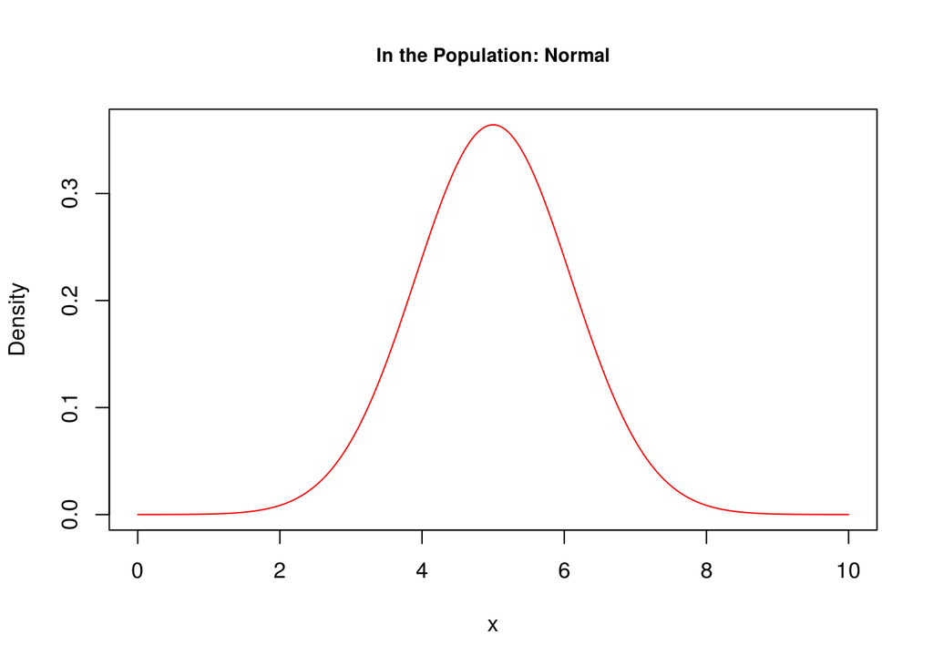

```r
## -- let's plot the Population Normal:
curve(dnorm(x,mu,sdev),
      from = 0,
      to = 10, n = 1000,
      col = "red",
      main = "In the Population: Normal",
      ylab = "Density",
      cex.main = .85)
```

```r
# in R: curve() is for ploting functions: ?curve
# dnorm is for Normal (Gaussian) Density: ?dnorm
# , and then: ?pnorm, ?rnorm, ?qnorm
```

The `curve()` function is a part of R’s {base} graphics functionality. R can do many more. Arguably, nothing compares with R in the world of data visualisatio; but you need to begin by making small steps since things there can get really complicated.

**Very important:** find some time to play around with `dnorm()`,`pnorm()`,`rnorm()`, and `qnorm()`. They are all probability functions. There will be a whole session on probability functions in R during this course, but it wouldn’t hurt you to take a look ahead.

```r
## -- Good. Let's draw some samples now:
s1 <- rnorm(100000, mu, sdev)
head(s1)
```

```
## [1] 5.398294 2.492257 4.635277 5.255937 4.767821 5.147136
```

What `rnorm()` does is the following: it takes a vector of 100,000 (in this case) elements and populates it with random deviates from the Gaussian with *mu* and *sigma* as its parameters. Please take into your consideration that `dnorm()`,`pnorm()`,`rnorm()`, and `qnorm()` all take the mean and **standard deviation** as their parameters, and **not variance**. We have termed the populaton standard deviation `sdev` here, and we use (somewhat incorrectly) `sigma` for population variance (it should be: **sigma<sup>2</sup>**, since standard deviation is the square root of variance, right…).

What are the sample statistics == **the estimates of the population parameters** from this sample alone?

```r
# Estimates?
mean(s1) # sample mean
```

```
## [1] 4.997079
```

```r
sd(s1) # sample standard deviation
```

```
## [1] 1.09638
```

```r
var(s1) # sample variance, not so bad...
```

```
## [1] 1.202049
```

What we will do next is the following. We draw 1,000 random samples from our theoretical, population distribution, using `mu` and `sigma` as its parameters, still pretending that we know their values with certainty. Each sample has a size of 100,000. Each time we draw a sample, we take its mean and its variance and store into the `estimates` data frame:

```r
## --  Ok. Now...
estimates <- data.frame(
  mean = sapply(seq(1:1000), function(x){
    mean(rnorm(100000,mu,sdev))
    }),
  var =
    sapply(seq(1:1000), function(x){
      var(rnorm(100000,mu,sdev))
    })
)
summary(estimates)
```

```
##       mean            var
##  Min.   :4.983   Min.   :1.182
##  1st Qu.:4.998   1st Qu.:1.196
##  Median :5.000   Median :1.200
##  Mean   :5.000   Mean   :1.200
##  3rd Qu.:5.002   3rd Qu.:1.204
##  Max.   :5.009   Max.   :1.217
```

*NOTE:* learn about `?sapply`. Compare `sapply()` with `lapply()` and figure out what the former does. Remember the `unlist(lapply(x,fun(x)))` syntax?

In estimation theory, the *estimator bias* is defined as the difference between the expected value of the estimate (i.e. its mean) and its true value:

```r
## --  How biased are these estimates?
mean_Bias <- mean(estimates$mean) - mu
mean_Bias
```

```
## [1] -0.0001401709
```

And what about the bias of the variance estimate?

```r
var_Bias <- mean(estimates$var) - sigma
var_Bias
```

```
## [1] 5.908921e-06
```

Did we forget about something? Go check whether R’s `var` and `mean` compute (a) **the sample** variance and standard deviation, respectively, or (b) **the population** variance and standard deviation, respectively. Which should be used in order to **estimate** the variance? Why?

Let’s see now what happens when we truncate the samples from this normal distribution before estimation:

```r
## --  Ok. Now... truncating!
estimatesTrunc <- data.frame(
  mean = sapply(seq(1:1000), function(x){
    rSample <- rnorm(100000, mu, sdev)
    quants <- quantile(rSample,c(.1,.9))
    rSample <- rSample[which(rSample>quants[1] & rSample<quants[2])]
    mean(rSample)
  }),
  var = sapply(seq(1:1000), function(x){
    rSample <- rnorm(100000, mu, sdev)
    quants <- quantile(rSample,c(.1,.9))
    rSample <- rSample[which(rSample>quants[1] & rSample<quants[2])]
    var(rSample)
    })
  )
summary(estimatesTrunc)
```

```
##       mean            var
##  Min.   :4.989   Min.   :0.5165
##  1st Qu.:4.997   1st Qu.:0.5232
##  Median :5.000   Median :0.5250
##  Mean   :5.000   Mean   :0.5252
##  3rd Qu.:5.002   3rd Qu.:0.5270
##  Max.   :5.011   Max.   :0.5344
```

In the previous code chunk, the following steps are performed:

- First, `rSample`, a random sample of size 100,000 is drawn from **Normal(mu,sigma)**;
- Second, the 10th and 90th distribution percentiles are computed by using R’s `quantile()` function: go learn about it `?quantile`;
- Third, `rSample` is truncated; by `rSample[which(rSample>quants[1] & rSample<quants[2])]` we keep only those elements of it which are higher than the sample’s 10th percentile and lower than its 90th percentile; go learn about `which()` which is one the most important functions in efficient R programming at all;
- Fourth, the truncated sample mean and variance are computed and stored in the `estimatesTrunc` data frame.

Now, we want to learn about the bias of the estimates obtained from the truncated samples:

```r
# And how biased are these estimates?
mean_BiasTrunc <- mean(estimatesTrunc$mean) - mu
mean_BiasTrunc
```

```
## [1] -0.0002371696
```

```r
var_BiasTrunc <- mean(estimatesTrunc$var) - sigma
var_BiasTrunc
```

```
## [1] -0.6748491
```

Let’s compare the biases of the estimates obtained from untruncated and truncated samples:

```r
# Let's compare:
mean_Bias < mean_BiasTrunc
```

```
## [1] FALSE
```

```r
var_Bias < var_BiasTrunc
```

```
## [1] FALSE
```

```r
# The difference?
mean_Bias - mean_BiasTrunc
```

```
## [1] 9.699871e-05
```

```r
var_Bias - var_BiasTrunc # ooops
```

```
## [1] 0.6748551
```

As of the **estimator variances**:

```r
# How about the variance of the estimates?
var(estimates$mean)/var(estimatesTrunc$mean)
```

```
## [1] 0.909443
```

```r
var(estimates$var)/var(estimatesTrunc$var) # oh oh oh...
```

```
## [1] 3.531827
```

Catch this: the **variance of** the variance estimate from the truncated sample is seriously shrinked **relatively to** the **variance of** the variance estimate from the untruncated sample! The next chunk uses {base} R’s `hist()` function to plot the distribution of the untruncated vs. truncated variance estimates from this experiment:

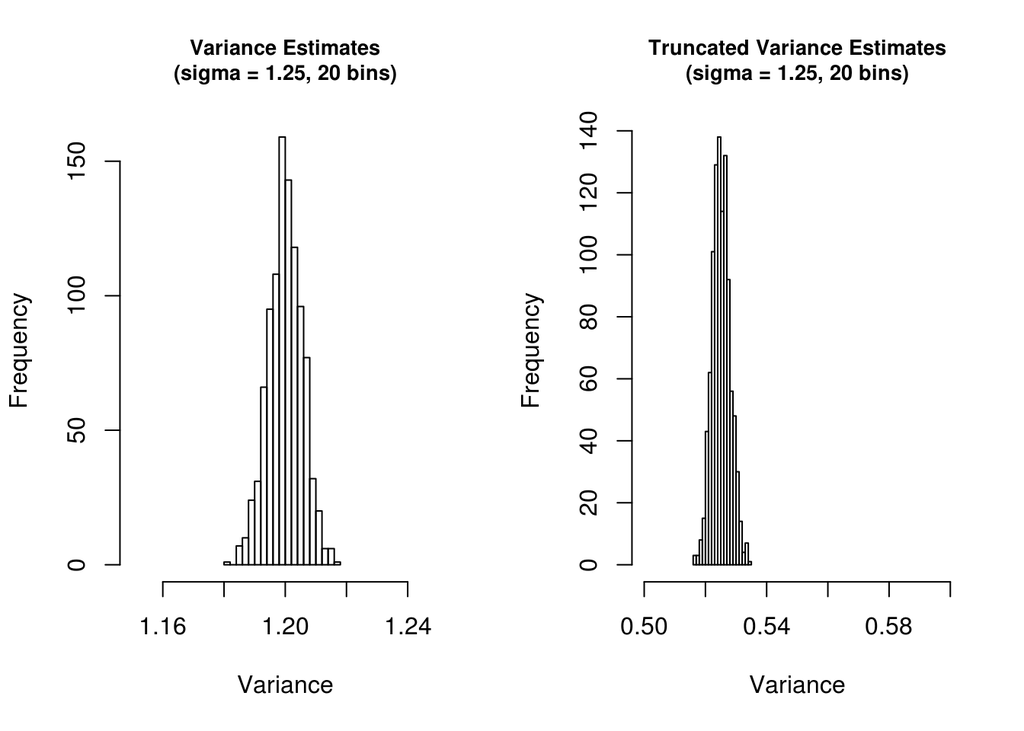

```r
## --  Let' see: histogram()
par(mfcol=c(1,2)) # this sets the plot parameters:
# R will plot with c(1,2), meaning: one row, two columns.
# The next two plots will thus be placed next to one another.
hist(estimates$var,20,
     main = "Variance Estimates\n(sigma = 1.25, 20 bins)",
     cex.main = .85,
     xlab = "Variance",
     xlim=c(1.15,1.25))
hist(estimatesTrunc$var,20,
     main = "Truncated Variance Estimates\n(sigma = 1.25, 20 bins)",
     cex.main = .85,
     xlab = "Variance",
     xlim=c(.5,.6))
```

```r
par(mfcol=c(1,1)) # reset plot parameters (do NOT forget to do this)
```

Do: `?hist()`. Be careful when it comes to the `breaks` argument.

We will perform another set of statistical experiments in order to figure out the relationship between the normal estimates from truncated and untruncated samples in a more systematic way.

```r
## -- Another set of statistical experiments

# Step 1 : Keep population sd = 1.5, vary population mean:
sampleMeansTrunc <- sapply(seq(5,50,5), function(x) {
  rSample <- rnorm(100000,x,1.5)
  quants <- quantile(rSample,c(.1,.9))
  rSample <- rSample[which(rSample>quants[1] & rSample<quants[2])]
  mean(rSample)
  })
plotFrameMeans <- data.frame(theoretical = seq(5,50,5),
                        empirical = sampleMeansTrunc)
plotFrameMeans
```

```
##    theoretical empirical
## 1            5  4.998965
## 2           10 10.003576
## 3           15 15.004202
## 4           20 19.997297
## 5           25 24.997272
## 6           30 29.995967
## 7           35 34.997453
## 8           40 40.004192
## 9           45 45.005413
## 10          50 50.002028
```

It should be clear what has happening above by now. How did we vary the population means in the this example?

Until now we have used only {base} R plots. We will switch to {ggplot2} now to demonstrate some of its functionality.

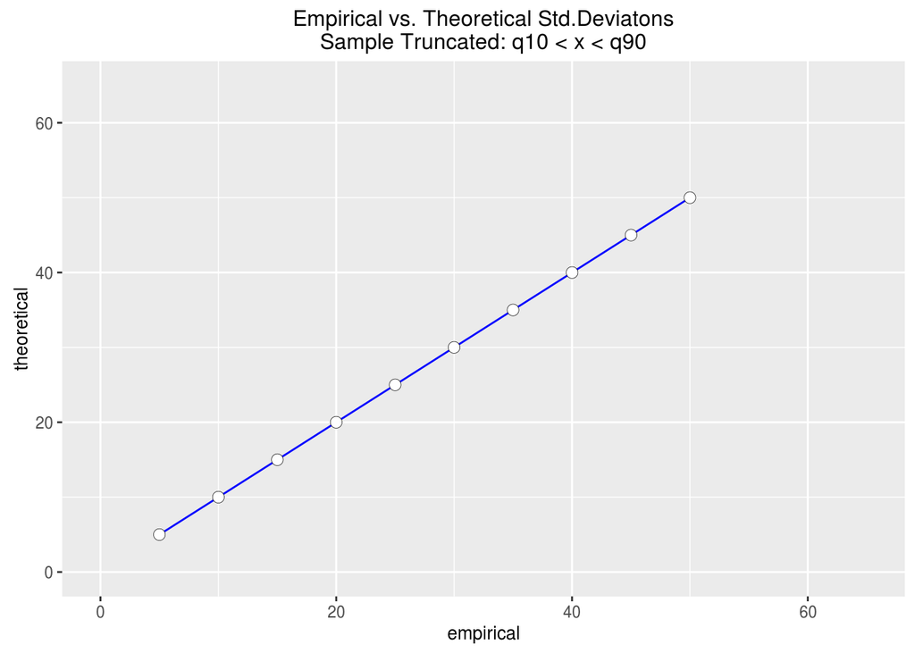

```r
ggplot(plotFrameMeans, aes(x = empirical, y = theoretical)) +
  geom_path(color="blue") +
  geom_point(colour="black", size = 2.5) +
  geom_point(colour="white", size = 2.25) +
  xlim(0,65) + ylim(0,65) +
  ggtitle("Empirical vs. Theoretical Std.Deviatons\nSample Truncated: q10 < x < q90") +
  theme(title = element_text(size = 10))
```

Without dwelling into {ggplot2} deeply at this point:

- the first argument to `ggplot` was the `plotFrameMeans` data frame;
- the `aes()` part defines *plot aesthetics*, on this ocassion informing R that the column `empirical` of `plotFrameMeans` goes on the x-axis while `theoretical` goes on the y-axis;
- `geom_path()` has linked the points produced by two `geom_point()` calls by blue lines; the two `geom_point()` calls were made in order to produce a white marker of `size = 2.25` on a black marker background of `size = 2.5` and “simulate” a marker outline;
- `xlim` and `ylim`, as their names suggest, set the range of the x- and y-axis, respectively;
- `ggtitle()`, obviously, does the title of the plot
- `theme()` is used to set the values of various plot objects; we have used it to fix the size of the title text.

Now, inspect the plot, and answer to this question: what is the relationship between the mean estimates obtained from untruncated and truncated samples drawn from the same population Gaussian?

Good. Now we fix the mean in the population and play around with population variance:

```r
# Step 2: Now keep population mean = 15, vary population variance:
sampleVarsTrunc <- sapply(seq(1,20,1), function(x) {
  rSample <- rnorm(100000,15,x)
  quants <- quantile(rSample,c(.1,.9))
  rSample <- rSample[which(rSample>quants[1] & rSample<quants[2])]
  var(rSample)
})
plotFrameVars <- data.frame(population = seq(1,20,1)^2,
                        estimated = sampleVarsTrunc)
plotFrameVars
```

```
##    population   estimated
## 1           1   0.4377041
## 2           4   1.7406756
## 3           9   3.9564182
## 4          16   6.9982687
## 5          25  10.9598762
## 6          36  15.6715349
## 7          49  21.2609452
## 8          64  27.9694764
## 9          81  35.3701244
## 10        100  44.0334657
## 11        121  52.9414562
## 12        144  63.8670380
## 13        169  73.6103739
## 14        196  86.3499917
## 15        225  97.9834633
## 16        256 112.3777574
## 17        289 126.3080003
## 18        324 141.3825104
## 19        361 158.3824375
## 20        400 175.7437472
```

{ggplot2}, again: the red line placed in the following plot by `geom_line(aes(x = plotFrameVars$population, y = plotFrameVars$population), color = "red")` is the identity line for the population (“theoretical”) variance: if the estimates were absolutely correct, they would all lie on it.

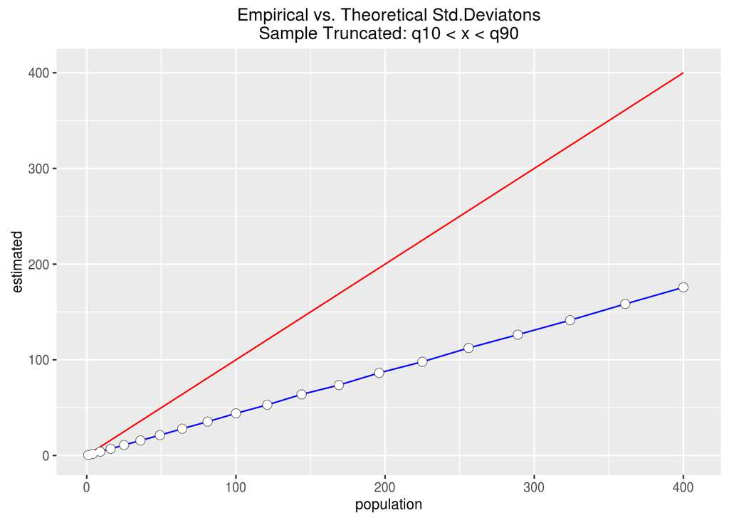

```r
ggplot(plotFrameVars, aes(y = estimated, x = population)) +
  geom_line(aes(x = plotFrameVars$population, y = plotFrameVars$population),
            color = "red") +
  geom_path(color="blue") +
  geom_point(colour="black", size = 2.5) +
  geom_point(colour="white", size = 2.25) +
  xlim(0,405) + ylim(0,405) +
  ggtitle("Empirical vs. Theoretical Std.Deviatons\nSample Truncated: q10 < x < q90") +
  theme(title = element_text(size = 10))
```

We repeat the experiment, but the truncate the sample at the usual -3SD < x < +3SD (approx. 99.7% of data under the Normal are found there, so it does not seem that we’re really loosing too much, right?):

```r
## -- What if we truncate mean(x)-3SD < x < mean(x)+3SD in Step 2?
sampleVarsTrunc <- sapply(seq(3,20,1), function(x) {
  rSample <- rnorm(100000,15,x)
  quants <- c(mean(rSample)-3*sd(rSample), mean(rSample)+3*sd(rSample))
  rSample <- rSample[which(rSample>quants[1] & rSample<quants[2])]
  var(rSample)
})
plotFrameVars <- data.frame(population = seq(3,20,1)^2,
                            estimated = sampleVarsTrunc)
plotFrameVars
```

```
##    population  estimated
## 1           9   8.752084
## 2          16  15.435501
## 3          25  24.353258
## 4          36  35.051174
## 5          49  47.664695
## 6          64  62.041212
## 7          81  78.481222
## 8         100  98.238521
## 9         121 117.945867
## 10        144 138.825683
## 11        169 163.824704
## 12        196 189.213495
## 13        225 218.825399
## 14        256 250.506609
## 15        289 281.816349
## 16        324 313.754527
## 17        361 352.323988
## 18        400 388.684592
```

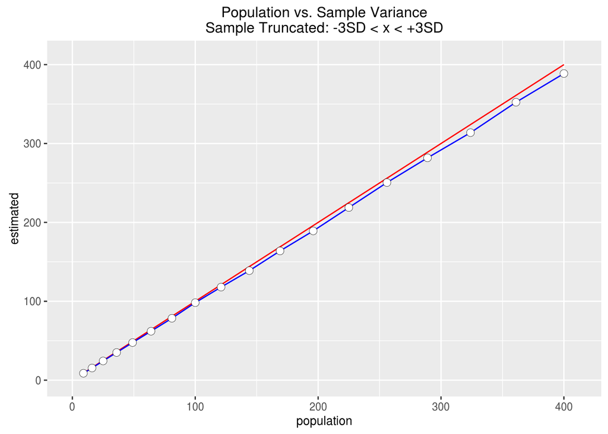

```r
ggplot(plotFrameVars, aes(y = estimated, x = population)) +
  geom_line(aes(x = plotFrameVars$population, y = plotFrameVars$population),
            color = "red") +
  geom_path(color="blue") +
  geom_point(colour="black", size = 2.5) +
  geom_point(colour="white", size = 2.25) +
  xlim(0,410) + ylim(0,410) +
  ggtitle("Population vs. Sample Variance\nSample Truncated: -3SD < x < +3SD") +
  theme(title = element_text(size = 10))
```

Finally, it should get worse if we go for -2SD < x < +2SD? Am I right?

*CONTEMPLATE TRUNCATED SAMPLES DEEPLY AND DO NOT LOSE FAITH IN HUMANITY*

*until Session 04, 28 Nov/2016, where we will talk about strings in R :)*

```r
## -- What if we truncate mean(x)-2SD < x < mean(x)+2SD in Step 2?
sampleVarsTrunc <- sapply(seq(3,20,1), function(x) {
  rSample <- rnorm(100000,15,x)
  quants <- c(mean(rSample)-2*sd(rSample), mean(rSample)+2*sd(rSample))
  rSample <- rSample[which(rSample>quants[1] & rSample<quants[2])]
  var(rSample)
})
plotFrameVars <- data.frame(population = seq(3,20,1)^2,
                            estimated = sampleVarsTrunc)

plotFrameVars
```

```
##    population  estimated
## 1           9   6.959325
## 2          16  12.407556
## 3          25  19.144711
## 4          36  27.787721
## 5          49  37.827754
## 6          64  49.554710
## 7          81  62.599411
## 8         100  77.256057
## 9         121  93.583721
## 10        144 111.568198
## 11        169 130.426809
## 12        196 150.902896
## 13        225 175.394950
## 14        256 200.654401
## 15        289 222.748953
## 16        324 251.984047
## 17        361 278.605430
## 18        400 308.174109
```

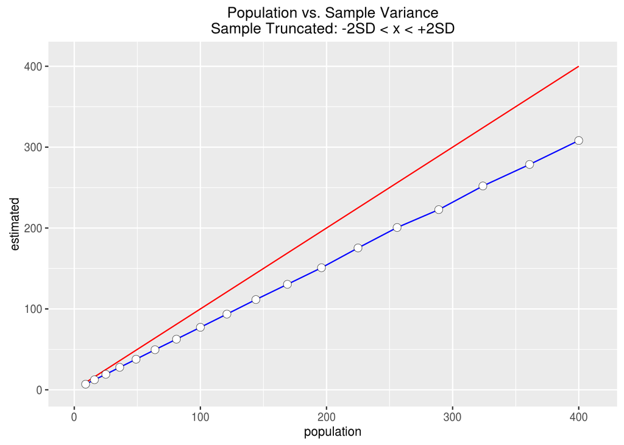

```r
ggplot(plotFrameVars, aes(y = estimated, x = population)) +
  geom_line(aes(x = plotFrameVars$population, y = plotFrameVars$population),
            color = "red") +
  geom_path(color="blue") +
  geom_point(colour="black", size = 2.5) +
  geom_point(colour="white", size = 2.25) +
  xlim(0,410) + ylim(0,410) +
  ggtitle("Population vs. Sample Variance\nSample Truncated: -2SD < x < +2SD") +
  theme(title = element_text(size = 10))
```

#### [Data Science Serbia](http://www.datascience.rs) 2016.